# Самостоятельная работа по введению в многоуровневую регрессию

1. Подключите следующие пакеты:

rio, tidyverse, skimr, sjPlot, lme4, lmerTest, lattice

```r
library(rio)
library(tidyverse)
library(skimr)
library(sjPlot)
library(lme4)
library(lmerTest)
library(lattice)
```

2. Загрузите данные timss15_math.csv и подготовьте их для работы

```r
data <- import("timss15_math.csv")

data$area <- as.factor(data$area)
data$itsex <- as.factor(data$itsex)
data$like_math <- as.factor(data$like_math)
data$par_edu <- as.factor(data$par_edu)


data$city <- fct_collapse(data$area, urban = c("Urban, densely populated", "Medium size city or large town"), other = c("Suburban, on fringe of urban area", "Remote rural", "Small town or village"))
```

Стандартизируйте баллы ученика по математике и шкалу интереса к математике и посмотрите на описательные статистики базы данных

```r
data$math_achiev_sd <- (data$math_achiev - mean(data$math_achiev)) / sd(data$math_achiev)

data$like_math_scl_sd <- (data$like_math_scl - mean(data$like_math_scl)) / sd(data$like_math_scl)

skim(data)
```

```
## Skim summary statistics
##  n obs: 4765
##  n variables: 22
```

```
##
## Variable type: character
##       variable missing complete    n min max empty n_unique
##         bsdgsb       0     4765 4765  12  18     0        4
##       bull_scl       0     4765 4765   6  18     0      103
##  conf_math_scl       0     4765 4765   6  18     0      131
##
## Variable type: factor
##   variable missing complete    n n_unique
##       area       0     4765 4765        5
##       city       0     4765 4765        2
##      itsex       0     4765 4765        2
##  like_math       0     4765 4765        3
##    par_edu       0     4765 4765        4
##                                top_counts ordered
##  Urb: 1554, Med: 1394, Sub: 692, Rem: 640   FALSE
##               urb: 2948, oth: 1817, NA: 0   FALSE
##               Mal: 2474, Fem: 2291, NA: 0   FALSE
##     Lik: 2295, Do : 1575, Ver: 895, NA: 0   FALSE
##   No : 2164, Hig: 1975, Don: 601, Unk: 25   FALSE
##
## Variable type: integer
##   variable missing complete    n     mean       sd    p0    p25   p50
##    idclass       0     4765 4765 10366.12  5992.36   102   5301 10401
##   idschool       0     4765 4765   103.64    59.92     1     53   104
##     idstud       0     4765 4765 1e+06    6e+05    10201 530109 1e+06
##  teach_exp     107     4658 4765    23.15    11.17     1     15    25
##      p75  p100     hist
##    15702 20401 ▇▆▇▇▇▇▇▇
##      157   204 ▇▆▇▇▇▇▇▇
##  1570212 2e+06 ▇▆▇▇▇▇▇▇
##       32    50 ▅▃▆▆▇▇▃▁
##
## Variable type: logical
##      variable missing complete    n mean count
##  conf_sci_scl    4765        0 4765  NaN  4765
##  like_sci_scl    4765        0 4765  NaN  4765
##
## Variable type: numeric
##          variable missing complete    n      mean     sd     p0    p25
##     like_math_scl       0     4765 4765  10.06      1.56   4.97   9.13
##  like_math_scl_sd       0     4765 4765  -3.4e-16   1     -3.26  -0.6
##       math_achiev       0     4765 4765 538.44     78.54 298.47 483.74
##    math_achiev_sd       0     4765 4765   1.8e-16   1     -3.06  -0.7
##            matwgt       0     4765 4765 258.99    146.59  59.23 189.29
##        sci_achiev       0     4765 4765 545.02     72.39 305.1  497.3
##            st_age       0     4765 4765  14.76      0.42  13.25  14.5
##            totwgt       0     4765 4765 263.02    155.43  77.53 190.34
##      p50    p75    p100     hist
##    9.87   10.92   13.98 ▁▁▂▆▇▃▂▁
##   -0.13    0.54    2.5  ▁▁▂▆▇▃▂▁
##  541.53  595.5   761.34 ▁▂▅▇▇▆▂▁
##    0.039   0.73    2.84 ▁▂▅▇▇▆▂▁
##  234.12  270.73 1118.35 ▃▇▁▁▁▁▁▁
##  548.97  594.72  774.97 ▁▁▃▆▇▅▁▁
##   14.75   15      17.67 ▁▂▇▆▁▁▁▁
##  234.36  270.73 1118.35 ▅▇▁▁▁▁▁▁
```

3. Постройте диаграмму рассеяния для оценки связи баллов по математике и шкалы интереса к математике (like_math_scl)

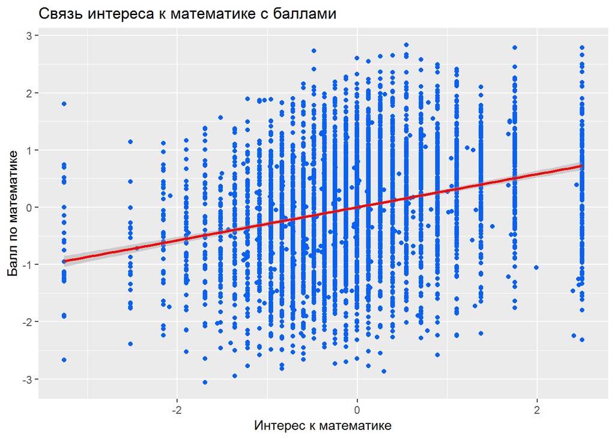

```r
  ggplot(data = data, aes(x = like_math_scl_sd, y = math_achiev_sd)) +
  geom_point(col = "#0761f2") +
  geom_smooth(method = "lm", col = "#f10606") +
  labs(x = 'Интерес к математике', y = 'Балл по математике', title = 'Связь интереса к математике с баллами')
```

Каково направление связи?

*Связь положительная*

Постройте регрессию с баллами по математике в качестве зависимой переменной и интересом к математике в качестве независимой

```r
mod_lm <- lm(data = data, math_achiev_sd ~ like_math_scl_sd)
summary(mod_lm)
```

```
##
## Call:
## lm(formula = math_achiev_sd ~ like_math_scl_sd, data = data)
##
## Residuals:
##      Min       1Q   Median       3Q      Max
## -3.03926 -0.66733  0.03894  0.67149  2.86632
##
## Coefficients:
##                   Estimate Std. Error t value Pr(>|t|)
## (Intercept)      3.158e-16  1.387e-02    0.00        1
## like_math_scl_sd 2.893e-01  1.387e-02   20.86   <2e-16 ***
## ---
## Signif. codes:  0 '***' 0.001 '**' 0.01 '*' 0.05 '.' 0.1 ' ' 1
##
## Residual standard error: 0.9573 on 4763 degrees of freedom
## Multiple R-squared:  0.08368,    Adjusted R-squared:  0.08348
## F-statistic: 434.9 on 1 and 4763 DF,  p-value: < 2.2e-16
```

Опишите получившуюся модель.

*Интерес к математике связан с баллами TIMSS положительно: при увеличении шкалы интерса к математике на одно стандартное отклонение, балл растет на 0,29 стандартного отклонения, связь значима на уровне p<0,001. Модель объясняет 8,34% дисперсии.*

4. Постройте базовую многоуровневую модель, где варьируется только интерцепт

```r
base <- lmer(data = data, math_achiev_sd ~ (1 | idclass), REML = FALSE)
summary(base)
```

```
## Linear mixed model fit by maximum likelihood . t-tests use
##   Satterthwaite's method [lmerModLmerTest]
## Formula: math_achiev_sd ~ (1 | idclass)
##    Data: data
##
##      AIC      BIC   logLik deviance df.resid
##  11700.8  11720.2  -5847.4  11694.8     4762
##
## Scaled residuals:
##     Min      1Q  Median      3Q     Max
## -3.1714 -0.6672  0.0106  0.6737  3.8212
##
## Random effects:
##  Groups   Name        Variance Std.Dev.
##  idclass  (Intercept) 0.3996   0.6321
##  Residual             0.6019   0.7759
## Number of obs: 4765, groups:  idclass, 221
##
## Fixed effects:
##               Estimate Std. Error         df t value Pr(>|t|)
## (Intercept)  -0.003551   0.044221 220.874068   -0.08    0.936
```

Опишите все параметры модели.

*Общегрупповой интерцепт (grand mean) значимо не отличается от 0. Дисперсия остатков на индивидуальном уровне (внутригрупповая дисперсия) выше, чем дисперсия между группами (0,6 и 0,4, соответственно). Это означает, что зависимая переменная объясняется больше различиями между учениками, чем между классами.*

Визуализируйте рандомную часть этой модели

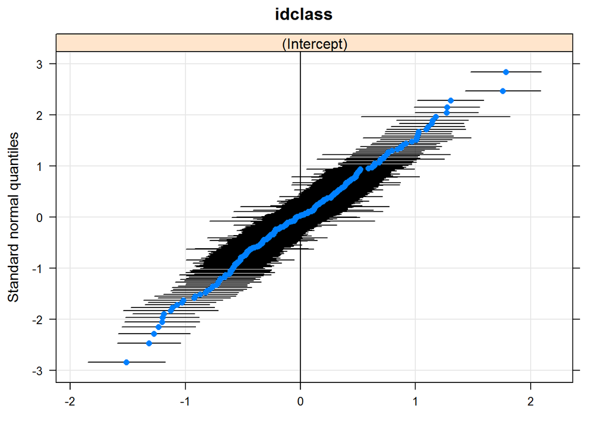

```r
qqmath(ranef(base, condVar = TRUE))
```

Что на осях X и Y? О чем говорит этот график?

*По оси X - значения интерцепта, по оси Y - квантили распределения. На графике видно, что есть достаточно много классов, в которых интерцепт значимо отличается от 0 (синяя точка - значение интерцепта, черная линия - доверительный интервал).*

5. Постройте модель random intercept

```r
model1 <- lmer(data = data, math_achiev_sd ~ like_math_scl_sd + (1 | idclass), REML = FALSE)
summary(model1)
```

```
## Linear mixed model fit by maximum likelihood . t-tests use
##   Satterthwaite's method [lmerModLmerTest]
## Formula: math_achiev_sd ~ like_math_scl_sd + (1 | idclass)
##    Data: data
##
##      AIC      BIC   logLik deviance df.resid
##  11240.1  11266.0  -5616.1  11232.1     4761
##
## Scaled residuals:
##     Min      1Q  Median      3Q     Max
## -2.9663 -0.6645  0.0228  0.6762  3.5329
##
## Random effects:
##  Groups   Name        Variance Std.Dev.
##  idclass  (Intercept) 0.3720   0.6100
##  Residual             0.5456   0.7387
## Number of obs: 4765, groups:  idclass, 221
##
## Fixed effects:
##                    Estimate Std. Error         df t value Pr(>|t|)
## (Intercept)      -2.379e-03  4.263e-02  2.214e+02  -0.056    0.956
## like_math_scl_sd  2.535e-01  1.150e-02  4.639e+03  22.045   <2e-16 ***
## ---
## Signif. codes:  0 '***' 0.001 '**' 0.01 '*' 0.05 '.' 0.1 ' ' 1
##
## Correlation of Fixed Effects:
##             (Intr)
## lk_mth_scl_ 0.001
```

Как сильно различаются значения интерцептов? Какова связь интереса к математике с баллами по математике?

*Связь интереса к математике с баллами TIMSS положительная: при увеличении шкалы интереса на одно стандарное отклонение, балл уеличивается на 0,25 стандартного отклонения. Что касается random effects, то дисперсия внутри групп больше, чем межгрупповая дисперсия (0,55 и 0,37, соответственно), что говорит о том, что вклад индивидуальных различий в объяснение зависимой переменной больше, чем межгрупповых.*

Визуализируйте получившуюся модель

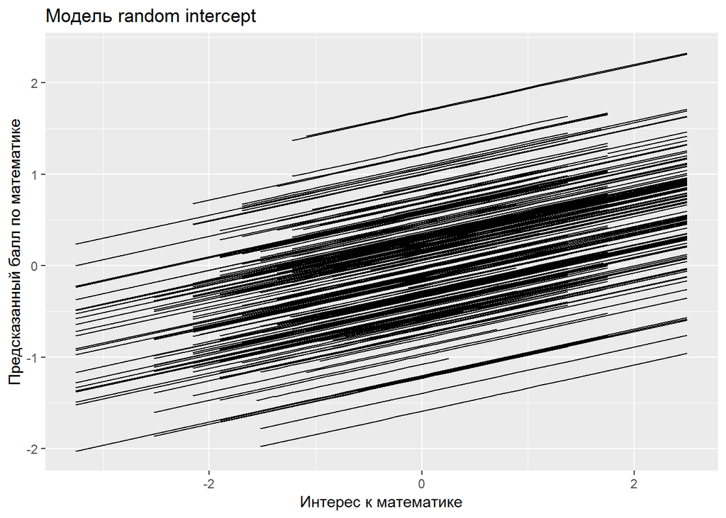

```r
data$pred_math <- ifelse(is.na(data$like_math_scl_sd), NA, fitted(model1))

ggplot(data, aes(x=like_math_scl_sd, y = pred_math, group = idclass))  +
    geom_line() +
    labs(x = 'Интерес к математике', y = 'Предсказанный балл по математике', title = 'Модель random intercept')
```

6. Постройте модель random intercept, random slope uncorrelated

```r
model2 <- lmer(data = data, math_achiev_sd ~ like_math_scl_sd + (like_math_scl_sd || idclass))
summary(model2)
```

```
## Linear mixed model fit by REML. t-tests use Satterthwaite's method [
## lmerModLmerTest]
## Formula: math_achiev_sd ~ like_math_scl_sd + (like_math_scl_sd || idclass)
##    Data: data
##
## REML criterion at convergence: 11242
##
## Scaled residuals:
##     Min      1Q  Median      3Q     Max
## -2.9681 -0.6626  0.0220  0.6752  3.4146
##
## Random effects:
##  Groups    Name             Variance Std.Dev.
##  idclass   (Intercept)      0.372972 0.61071
##  idclass.1 like_math_scl_sd 0.003333 0.05773
##  Residual                   0.542780 0.73674
## Number of obs: 4765, groups:  idclass, 221
##
## Fixed effects:
##                    Estimate Std. Error         df t value Pr(>|t|)
## (Intercept)      -4.684e-04  4.270e-02  2.203e+02  -0.011    0.991
## like_math_scl_sd  2.536e-01  1.226e-02  1.859e+02  20.676   <2e-16 ***
## ---
## Signif. codes:  0 '***' 0.001 '**' 0.01 '*' 0.05 '.' 0.1 ' ' 1
##
## Correlation of Fixed Effects:
##             (Intr)
## lk_mth_scl_ 0.002
```

Как сильно различаются значения интерцептов? Slope? Какова связь интереса к математике с баллами по математике?

*В целом связь интереса к математике и баллом TIMSS такая же, как в предыдущей модели: коэффициент 0,25 значим на уровне p<0,001. Дисперсия для slope крайне мала - 0,003, что говорит о том, что большинство slope крайне похожи.*

Визуализируйте получившуюся модель

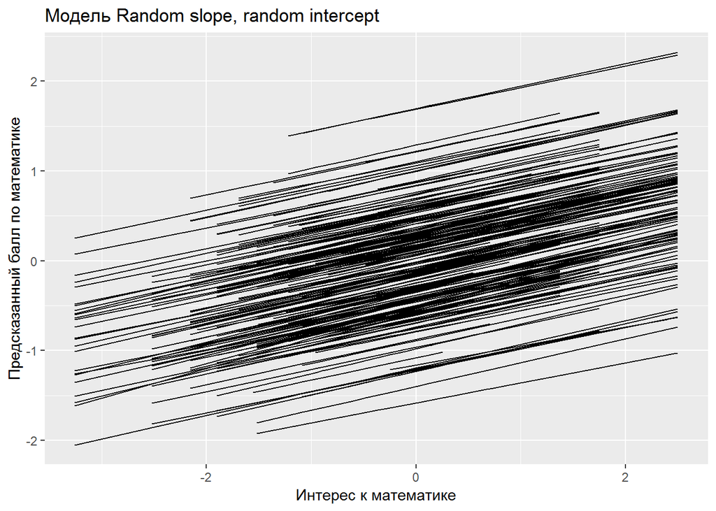

```r
data$pred_math2 <- fitted(model2)

ggplot(data, aes(x= like_math_scl_sd, y = pred_math2 , group = idclass))  +
    geom_line() +
    labs(x = 'Интерес к математике', y = 'Предсказанный балл по математике', title = 'Модель Random slope, random intercept')
```

7. Сравните модели

```r
anova(model1, model2)
```

```
## refitting model(s) with ML (instead of REML)
```

```
## Data: data
## Models:
## model1: math_achiev_sd ~ like_math_scl_sd + (1 | idclass)
## model2: math_achiev_sd ~ like_math_scl_sd + (like_math_scl_sd || idclass)
##        Df   AIC   BIC  logLik deviance Chisq Chi Df Pr(>Chisq)
## model1  4 11240 11266 -5616.1    11232
## model2  5 11240 11273 -5615.3    11230 1.568      1     0.2105
```

Какая лучше подходит данным?

*Разницы между моделями нет - как мы видели ранее, slope несильно варьируется в разных классах.*

8. Добавьте в модель из пункта 4 тип населенного пункта (city), затем добавьте тип населенного пункта в модель, выбранную в предыдущем пункте. Опишите результаты.

```r
base_city <- lmer(data = data, math_achiev_sd ~ city + (1 | idclass), REML = FALSE)
summary(base_city)
```

```
## Linear mixed model fit by maximum likelihood . t-tests use
##   Satterthwaite's method [lmerModLmerTest]
## Formula: math_achiev_sd ~ city + (1 | idclass)
##    Data: data
##
##      AIC      BIC   logLik deviance df.resid
##  11697.6  11723.5  -5844.8  11689.6     4761
##
## Scaled residuals:
##     Min      1Q  Median      3Q     Max
## -3.1783 -0.6676  0.0153  0.6721  3.8139
##
## Random effects:
##  Groups   Name        Variance Std.Dev.
##  idclass  (Intercept) 0.3887   0.6234
##  Residual             0.6020   0.7759
## Number of obs: 4765, groups:  idclass, 221
##
## Fixed effects:
##              Estimate Std. Error        df t value Pr(>|t|)
## (Intercept)   0.08408    0.05804 213.78494   1.449   0.1489
## cityother    -0.20190    0.08808 221.96287  -2.292   0.0228 *
## ---
## Signif. codes:  0 '***' 0.001 '**' 0.01 '*' 0.05 '.' 0.1 ' ' 1
##
## Correlation of Fixed Effects:
##           (Intr)
## cityother -0.659
```

```r
#Так как модели значимо не различаются, берем ту, которая проще - random intercept (model 1)
model3 <- lmer(data = data, math_achiev_sd ~ like_math_scl_sd + city + (1 | idclass), REML = FALSE)
summary(model3)
```

```
## Linear mixed model fit by maximum likelihood . t-tests use
##   Satterthwaite's method [lmerModLmerTest]
## Formula: math_achiev_sd ~ like_math_scl_sd + city + (1 | idclass)
##    Data: data
##
##      AIC      BIC   logLik deviance df.resid
##  11235.4  11267.7  -5612.7  11225.4     4760
##
## Scaled residuals:
##     Min      1Q  Median      3Q     Max
## -2.9600 -0.6661  0.0187  0.6745  3.5239
##
## Random effects:
##  Groups   Name        Variance Std.Dev.
##  idclass  (Intercept) 0.3589   0.5991
##  Residual             0.5457   0.7387
## Number of obs: 4765, groups:  idclass, 221
##
## Fixed effects:
##                    Estimate Std. Error         df t value Pr(>|t|)
## (Intercept)         0.09399    0.05575  214.20695   1.686  0.09324 .
## like_math_scl_sd    0.25392    0.01150 4640.55847  22.084  < 2e-16 ***
## cityother          -0.22198    0.08459  222.31081  -2.624  0.00929 **
## ---
## Signif. codes:  0 '***' 0.001 '**' 0.01 '*' 0.05 '.' 0.1 ' ' 1
##
## Correlation of Fixed Effects:
##             (Intr) lk_m__
## lk_mth_scl_  0.008
## cityother   -0.659 -0.011
```

Какова связь интереса к математике и типа населенного пункта с балами по математике? Какие параметры изменяются в выбранных моделях и как?